# Predict Bike Sharing Demand with AutoGluon Template

## Project: Predict Bike Sharing Demand with AutoGluon

This notebook is a template with each step that you need to complete for the project.

Please fill in your code where there are explicit `?` markers in the notebook. You are welcome to add more cells and code as you see fit.

Once you have completed all the code implementations, please export your notebook as a HTML file so the reviews can view your code. Make sure you have all outputs correctly outputted.

`File-> Export Notebook As... -> Export Notebook as HTML`

There is a writeup to complete as well after all code implememtation is done. Please answer all questions and attach the necessary tables and charts. You can complete the writeup in either markdown or PDF.

Completing the code template and writeup template will cover all of the rubric points for this project.

The rubric contains "Stand Out Suggestions" for enhancing the project beyond the minimum requirements. The stand out suggestions are optional. If you decide to pursue the "stand out suggestions", you can include the code in this notebook and also discuss the results in the writeup file.

## Step 1: Create an account with Kaggle

### Create Kaggle Account and download API key

Below is example of steps to get the API username and key. Each student will have their own username and key.

1. Open account settings.

2. Scroll down to API and click Create New API Token.

3. Open up `kaggle.json` and use the username and key.


## Step 2: Download the Kaggle dataset using the kaggle python library

### Open up Sagemaker Studio and use starter template

1. Notebook should be using a `ml.t3.medium` instance (2 vCPU + 4 GiB)
2. Notebook should be using kernal: `Python 3 (MXNet 1.8 Python 3.7 CPU Optimized)`

### Install packages

```python
!pip install -U pip
!pip install -U setuptools wheel
!pip install -U "mxnet<2.0.0" bokeh==3.4.1
#bokeh==2.0.1
!pip install autogluon --no-cache-dir
# Without --no-cache-dir, smaller aws instances may have trouble installing
```

[output not shown]

### Setup Kaggle API Key

```python
# !echo "KAGGLE_USERNAME=yourkaggleusername" >> .env
# !echo "KAGGLE_KEY=yourkagglekey" >> .env
```

```python
!pip install python-dotenv
import os
from dotenv import dotenv_values

CONFIG = dotenv_values(".env")
os.environ["KAGGLE_USERNAME"] = CONFIG["KAGGLE_USERNAME"]
os.environ["KAGGLE_KEY"] = CONFIG["KAGGLE_KEY"]
```

### Download and explore dataset

### Go to the bike sharing demand competition and agree to the terms

```python
import zipfile

# Download the dataset, it will be in a .zip file so you'll need to unzip it as well.
!kaggle competitions download -c bike-sharing-demand

# Using zipfile to extract the data files into a new folder "data"
with zipfile.ZipFile("bike-sharing-demand.zip", 'r') as zip_ref:
    zip_ref.extractall('data')
```

```
bike-sharing-demand.zip: Skipping, found more recently modified local copy (use --force to force download)
```

```python
import pandas as pd
from autogluon.tabular import TabularPredictor

# Loads the train, test and submission datasets
train = pd.read_csv('train.csv')
test = pd.read_csv('test.csv')
submission = pd.read_csv('sampleSubmission.csv')
submission_new_features = submission
submission_new_hpo = submission
```

```python
# Create the train dataset in pandas by reading the csv
# Set the parsing of the datetime column so you can use some of the `dt` features in pandas later
train = pd.read_csv('train.csv', parse_dates=["datetime"])
train.dtypes
```

```
datetime      datetime64[ns]
season                 int64
holiday                int64
workingday             int64
weather                int64
temp                 float64
atemp                float64
humidity               int64
windspeed            float64
casual                 int64
registered             int64
count                  int64
dtype: object
```

```python
# Simple output of the train dataset to view some of the min/max/varition of the dataset features.
train.describe()
```

|  | datetime | season | holiday | workingday | weather | temp | atemp | humidity | windspeed | casual | registered | count |
| --- | --- | --- | --- | --- | --- | --- | --- | --- | --- | --- | --- | --- |
| count | 10886 | 10886.000000 | 10886.000000 | 10886.000000 | 10886.000000 | 10886.00000 | 10886.000000 | 10886.000000 | 10886.000000 | 10886.000000 | 10886.000000 | 10886.000000 |
| mean | 2011-12-27 05:56:22.399411968 | 2.506614 | 0.028569 | 0.680875 | 1.418427 | 20.23086 | 23.655084 | 61.886460 | 12.799395 | 36.021955 | 155.552177 | 191.574132 |
| min | 2011-01-01 00:00:00 | 1.000000 | 0.000000 | 0.000000 | 1.000000 | 0.82000 | 0.760000 | 0.000000 | 0.000000 | 0.000000 | 0.000000 | 1.000000 |
| 25% | 2011-07-02 07:15:00 | 2.000000 | 0.000000 | 0.000000 | 1.000000 | 13.94000 | 16.665000 | 47.000000 | 7.001500 | 4.000000 | 36.000000 | 42.000000 |
| 50% | 2012-01-01 20:30:00 | 3.000000 | 0.000000 | 1.000000 | 1.000000 | 20.50000 | 24.240000 | 62.000000 | 12.998000 | 17.000000 | 118.000000 | 145.000000 |
| 75% | 2012-07-01 12:45:00 | 4.000000 | 0.000000 | 1.000000 | 2.000000 | 26.24000 | 31.060000 | 77.000000 | 16.997900 | 49.000000 | 222.000000 | 284.000000 |
| max | 2012-12-19 23:00:00 | 4.000000 | 1.000000 | 1.000000 | 4.000000 | 41.00000 | 45.455000 | 100.000000 | 56.996900 | 367.000000 | 886.000000 | 977.000000 |
| std | NaN | 1.116174 | 0.166599 | 0.466159 | 0.633839 | 7.79159 | 8.474601 | 19.245033 | 8.164537 | 49.960477 | 151.039033 | 181.144454 |

```python
# Create the test pandas dataframe in pandas by reading the csv, remember to parse the datetime!
test = pd.read_csv('test.csv', parse_dates=["datetime"])
test.dtypes
```

```
datetime      datetime64[ns]
season                 int64
holiday                int64
workingday             int64
weather                int64
temp                 float64
atemp                float64
humidity               int64
windspeed            float64
dtype: object
```

```python
# Same thing as train and test dataset
submission = pd.read_csv('sampleSubmission.csv', parse_dates=['datetime'])
submission.head(2)
```

|  | datetime | count |
| --- | --- | --- |
| 0 | 2011-01-20 00:00:00 | 0 |
| 1 | 2011-01-20 01:00:00 | 0 |

## Step 3: Train a model using AutoGluon’s Tabular Prediction

Requirements:

- We are prediting `count`, so it is the label we are setting.
- Ignore `casual` and `registered` columns as they are also not present in the test dataset.
- Use the `root_mean_squared_error` as the metric to use for evaluation.
- Set a time limit of 10 minutes (600 seconds).
- Use the preset `best_quality` to focus on creating the best model.

```python
predictor = TabularPredictor(label='count',
                             problem_type='regression',
                             eval_metric='root_mean_squared_error',
                             learner_kwargs={"ignored_columns": ["casual", "registered"]}).fit(train_data = train,
                                                                                               time_limit=600,
                                                                                               presets='best_quality')
```

[output not shown]

[output cut: 37 more lines]

[output not shown]

[output not shown]

```
(_dystack pid=5936) 	-131.9758	 = Validation score   (-root_mean_squared_error)
(_dystack pid=5936) 	49.46s	 = Training   runtime
(_dystack pid=5936) 	16.9s	 = Validation runtime
(_dystack pid=5936) Fitting model: WeightedEnsemble_L2 ... Training model for up to 120.37s of the 32.98s of remaining time.
(_dystack pid=5936) 	Ensemble Weights: {'KNeighborsDist_BAG_L1': 1.0}
(_dystack pid=5936) 	-89.9155	 = Validation score   (-root_mean_squared_error)
(_dystack pid=5936) 	0.07s	 = Training   runtime
(_dystack pid=5936) 	0.0s	 = Validation runtime
(_dystack pid=5936) Fitting 106 L2 models, fit_strategy="sequential" ...
(_dystack pid=5936) Fitting model: LightGBMXT_BAG_L2 ... Training model for up to 32.80s of the 32.69s of remaining time.
(_dystack pid=5936) 	Fitting 8 child models (S1F1 - S1F8) | Fitting with ParallelLocalFoldFittingStrategy (8 workers, per: cpus=1, gpus=0, memory=1.01%)
```

```
(_ray_fit pid=11628) [1000]	valid_set's rmse: 76.9044
(_ray_fit pid=9672) [1000]	valid_set's rmse: 75.7436
(_ray_fit pid=25668) [2000]	valid_set's rmse: 77.338 [repeated 7x across cluster]
```

[output not shown]

[output cut: 87 more lines]

```
	Fitting 8 child models (S1F1 - S1F8) | Fitting with ParallelLocalFoldFittingStrategy (8 workers, per: cpus=1, gpus=0, memory=0.45%)
	-54.9865	 = Validation score   (-root_mean_squared_error)
	8.99s	 = Training   runtime
	0.45s	 = Validation runtime
Fitting model: RandomForestMSE_BAG_L2 ... Training model for up to 7.94s of the 7.67s of remaining time.
	-53.3578	 = Validation score   (-root_mean_squared_error)
	20.88s	 = Training   runtime
	1.2s	 = Validation runtime
Fitting model: WeightedEnsemble_L3 ... Training model for up to 360.00s of the -15.48s of remaining time.
	Ensemble Weights: {'RandomForestMSE_BAG_L2': 0.72, 'LightGBM_BAG_L2': 0.24, 'LightGBMXT_BAG_L2': 0.04}
	-53.0736	 = Validation score   (-root_mean_squared_error)
	0.07s	 = Training   runtime
	0.0s	 = Validation runtime
AutoGluon training complete, total runtime = 434.45s ... Best model: WeightedEnsemble_L3 | Estimated inference throughput: 39.4 rows/s (1361 batch size)
TabularPredictor saved. To load, use: predictor = TabularPredictor.load("C:\Users\OKKKKK\Documents\udacityawsmlprojects\Project 1 - bikesharingdemand\AutogluonModels\ag-20250527_122949")
```

### Review AutoGluon's training run with ranking of models that did the best.

```python
predictor.fit_summary()
```

```
*** Summary of fit() ***
Estimated performance of each model:
                     model   score_val              eval_metric  pred_time_val    fit_time  pred_time_val_marginal  fit_time_marginal  stack_level  can_infer  fit_order
0      WeightedEnsemble_L3  -53.073554  root_mean_squared_error      37.593806  308.818023                0.000000           0.069636            3       True         13
1   RandomForestMSE_BAG_L2  -53.357790  root_mean_squared_error      27.782576  270.600677                1.197615          20.877489            2       True         12
2          LightGBM_BAG_L2  -54.986463  root_mean_squared_error      27.033848  258.708721                0.448887           8.985533            2       True         11
3        LightGBMXT_BAG_L2  -60.723814  root_mean_squared_error      35.947304  278.885365                9.362343          29.162177            2       True         10
4    KNeighborsDist_BAG_L1  -84.146423  root_mean_squared_error       0.117025    0.179525                0.117025           0.179525            1       True          2
5      WeightedEnsemble_L2  -84.146423  root_mean_squared_error       0.121075    0.415373                0.004050           0.235849            2       True          9
6    KNeighborsUnif_BAG_L1 -101.588176  root_mean_squared_error       0.095239    0.127686                0.095239           0.127686            1       True          1
7   RandomForestMSE_BAG_L1 -116.548359  root_mean_squared_error       1.092729    7.676584                1.092729           7.676584            1       True          5
8     ExtraTreesMSE_BAG_L1 -124.600676  root_mean_squared_error       0.967765    3.722634                0.967765           3.722634            1       True          7
9          CatBoost_BAG_L1 -130.606258  root_mean_squared_error       0.111064  142.609752                0.111064         142.609752            1       True          6
10         LightGBM_BAG_L1 -131.054162  root_mean_squared_error       3.436427   13.427572                3.436427          13.427572            1       True          4
11       LightGBMXT_BAG_L1 -131.460909  root_mean_squared_error      19.606903   41.138092               19.606903          41.138092            1       True          3
12  NeuralNetFastAI_BAG_L1 -147.728575  root_mean_squared_error       1.157809   40.841344                1.157809          40.841344            1       True          8
Number of models trained: 13
Types of models trained:
{'WeightedEnsembleModel', 'StackerEnsembleModel_KNN', 'StackerEnsembleModel_RF', 'StackerEnsembleModel_XT', 'StackerEnsembleModel_NNFastAiTabular', 'StackerEnsembleModel_LGB', 'StackerEnsembleModel_CatBoost'}
Bagging used: True  (with 8 folds)
Multi-layer stack-ensembling used: True  (with 3 levels)
Feature Metadata (Processed):
(raw dtype, special dtypes):
('float', [])                : 3 | ['temp', 'atemp', 'windspeed']
('int', [])                  : 3 | ['season', 'weather', 'humidity']
('int', ['bool'])            : 2 | ['holiday', 'workingday']
('int', ['datetime_as_int']) : 5 | ['datetime', 'datetime.year', 'datetime.month', 'datetime.day', 'datetime.dayofweek']
Plot summary of models saved to file: C:\Users\OKKKKK\Documents\udacityawsmlprojects\Project 1 - bikesharingdemand\AutogluonModels\ag-20250527_122949\SummaryOfModels.html
*** End of fit() summary ***
```

[output not shown]

[output cut: 166 more lines]

```

     stack_level  can_infer  fit_order
 0             3       True         13
 1             2       True         12
 2             2       True         11
 3             2       True         10
 4             1       True          2
 5             2       True          9
 6             1       True          1
 7             1       True          5
 8             1       True          7
 9             1       True          6
 10            1       True          4
 11            1       True          3
 12            1       True          8  }
```

### Create predictions from test dataset

```python
# Note: By setting as_pandas=True, the predicted output will be returned as a Pandas DataFrame.
# predictor.predict(test_data, model='LightGBM')

predictions = predictor.predict(test)
predictions.head(2)
```

```
0    22.180981
1    42.248741
Name: count, dtype: float32
```

#### NOTE: Kaggle will reject the submission if we don't set everything to be > 0.

```python
# Describe the `predictions` series to see if there are any negative values
predictions.describe()
```

```
count    6493.000000
mean      100.442436
std        89.658806
min         3.656721
25%        19.456337
50%        64.224503
75%       166.807220
max       367.198669
Name: count, dtype: float64
```

```python
# How many negative values do we have?

# counting the negative values
negative_count = (predictions < 0).sum()
print(f'Negative values count: {negative_count}')
```

```
Negative values count: 0
```

```python
# Set them to zero
predictions[predictions < 0] = 0

negative_count = (predictions < 0).sum()
print(f'Negative values count: {negative_count}')
```

```
Negative values count: 0
```

### Set predictions to submission dataframe, save, and submit

```python
submission["count"] = predictions
submission.to_csv("submission1.csv", index=False)
```

```python
view_first_submission = pd.read_csv('submission1.csv')
view_first_submission.head(2)
```

|  | datetime | count |
| --- | --- | --- |
| 0 | 2011-01-20 00:00:00 | 22.18098 |
| 1 | 2011-01-20 01:00:00 | 42.24874 |

```python
!kaggle competitions submit -c bike-sharing-demand -f submission1.csv -m "first raw submission"
```

```
Successfully submitted to Bike Sharing Demand
```

```
  8%|8         | 16.0k/195k [00:00<00:05, 30.9kB/s]
 49%|####9     | 96.0k/195k [00:00<00:00, 189kB/s]
 74%|#######4  | 144k/195k [00:00<00:00, 226kB/s]
 99%|#########8| 192k/195k [00:00<00:00, 277kB/s]
```

#### View submission via the command line or in the web browser under the competition's page - `My Submissions`

```python
!pip install kaggle
```

```python
# Running the Kaggle command and storing the output in a variable
output = !kaggle competitions submissions -c bike-sharing-demand

# Displaying the first 6 lines
for line in output[:6]:
    print(line)
```

```
fileName                     date                        description                        status                     publicScore  privateScore
---------------------------  --------------------------  ---------------------------------  -------------------------  -----------  ------------
submission_new_hpo.csv       2025-05-27 13:01:55.393000  new features with hyperparameters  SubmissionStatus.COMPLETE  0.49398      0.49398
submission_new_features.csv  2025-05-27 12:53:24.687000  new features                       SubmissionStatus.COMPLETE  0.62281      0.62281
submission1.csv              2025-05-27 12:40:48.563000  first raw submission               SubmissionStatus.COMPLETE  1.79857      1.79857
submission1.csv              2025-05-23 12:50:44.947000  first raw submission               SubmissionStatus.COMPLETE  1.80029      1.80029
```

#### Initial score of `1.79857`

## Step 4: Exploratory Data Analysis and Creating an additional feature

- Any additional feature will do, but a great suggestion would be to separate out the datetime into hour, day, or month parts.

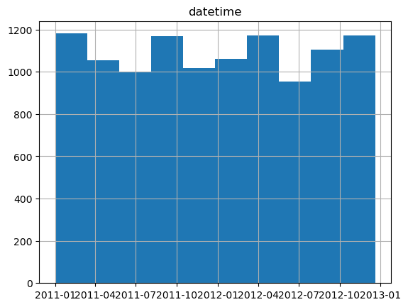

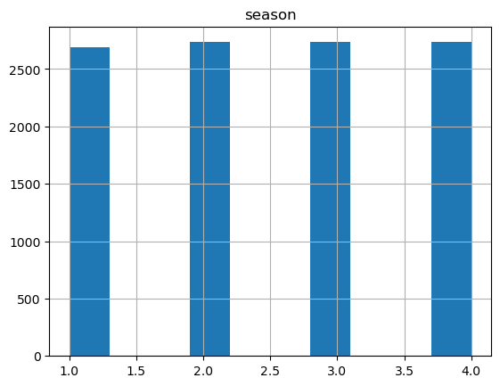

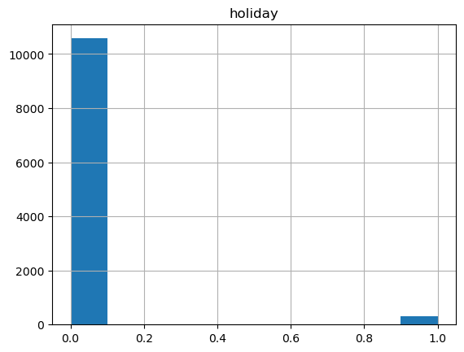

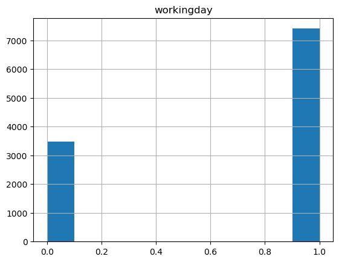

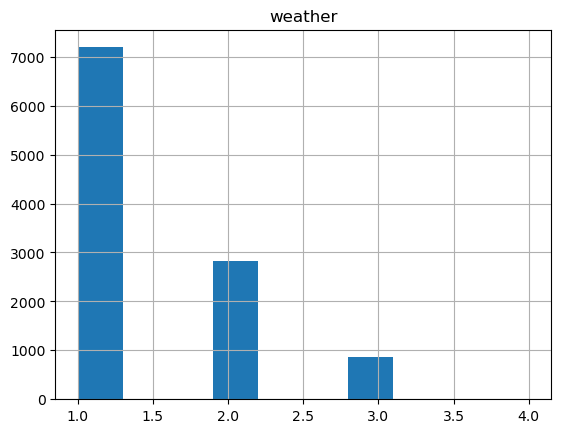

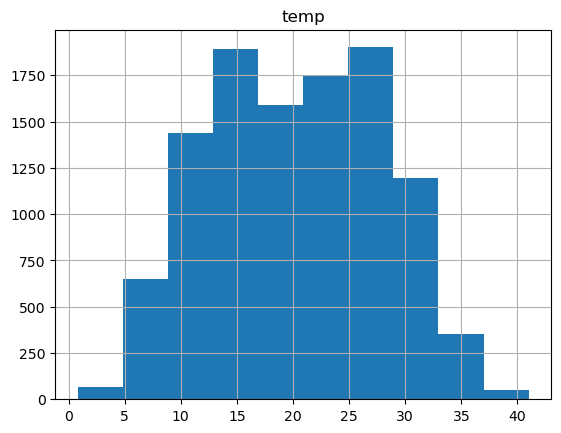

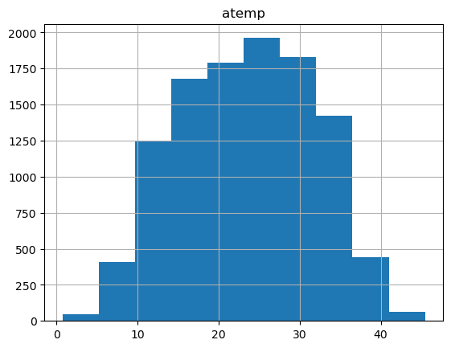

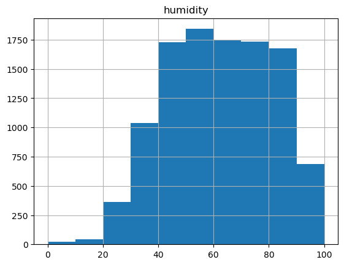

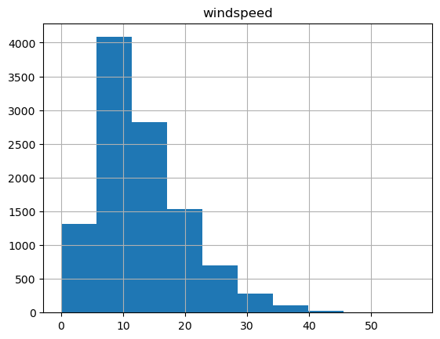

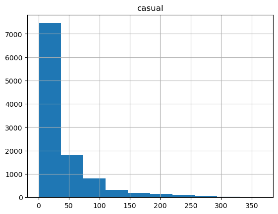

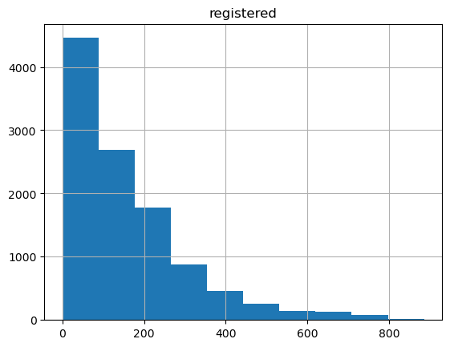

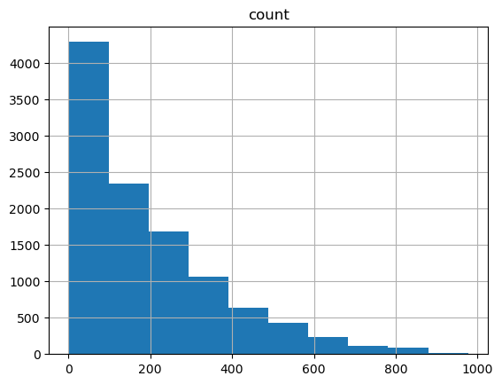

```python
# Create a histogram of all features to show the distribution of each one relative to the data. This is part of the exploritory data analysis
import matplotlib.pyplot as plt

# Increase the figure size
plt.figure(figsize=(10, 6))

for feature in train.columns:
    # Plot the histogram
    train.hist(column=feature)
    # Display the plot
    plt.show()
```

```python
# create a new feature

# create a new feature(s) for the train dataset
train['year'] = train['datetime'].dt.year
train['month'] = train['datetime'].dt.month
train['day'] = train['datetime'].dt.day
train['hour'] = train['datetime'].dt.hour
train['minute'] = train['datetime'].dt.minute
train['second'] = train['datetime'].dt.second

# create a new feature(s) for the test dataset
test['year'] = test['datetime'].dt.year
test['month'] = test['datetime'].dt.month
test['day'] = test['datetime'].dt.day
test['hour'] = test['datetime'].dt.hour
test['minute'] = test['datetime'].dt.minute
test['second'] = test['datetime'].dt.second
```

## Make category types for these so models know they are not just numbers

- AutoGluon originally sees these as ints, but in reality they are int representations of a category.
- Setting the dtype to category will classify these as categories in AutoGluon.

```python
train["season"] = train['season'].astype("category")
train["weather"] = train['weather'].astype("category")
test["season"] = test['season'].astype("category")
test["weather"] = test['weather'].astype("category")
```

```python
# View the new feature
train.head(2)
```

|  | datetime | season | holiday | workingday | weather | temp | atemp | humidity | windspeed | casual | registered | count | year | month | day | hour | minute | second |
| --- | --- | --- | --- | --- | --- | --- | --- | --- | --- | --- | --- | --- | --- | --- | --- | --- | --- | --- |
| 0 | 2011-01-01 00:00:00 | 1 | 0 | 0 | 1 | 9.84 | 14.395 | 81 | 0.0 | 3 | 13 | 16 | 2011 | 1 | 1 | 0 | 0 | 0 |
| 1 | 2011-01-01 01:00:00 | 1 | 0 | 0 | 1 | 9.02 | 13.635 | 80 | 0.0 | 8 | 32 | 40 | 2011 | 1 | 1 | 1 | 0 | 0 |

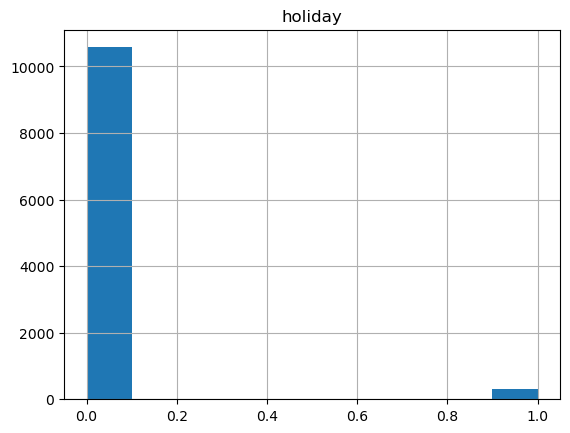

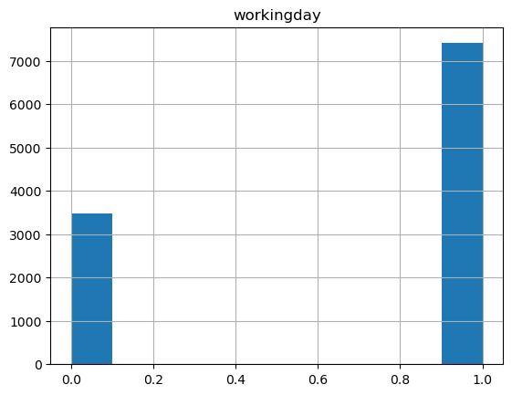

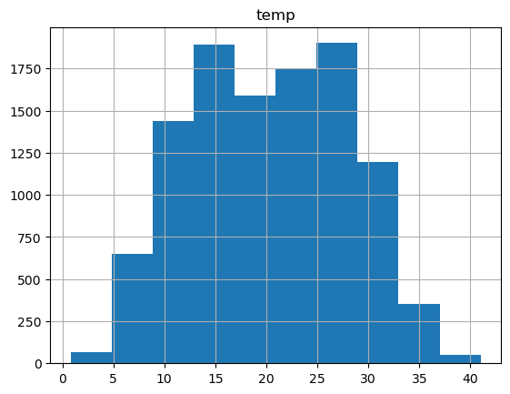

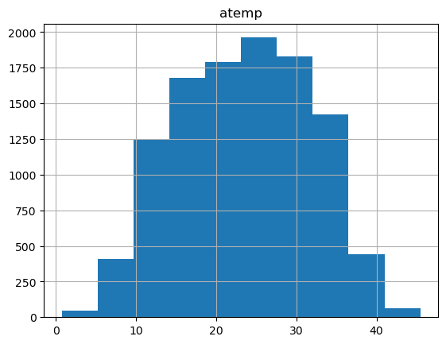

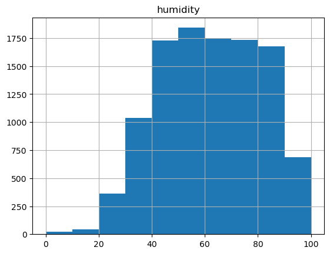

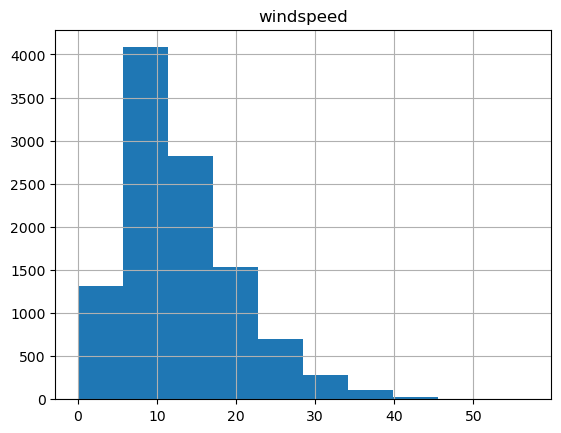

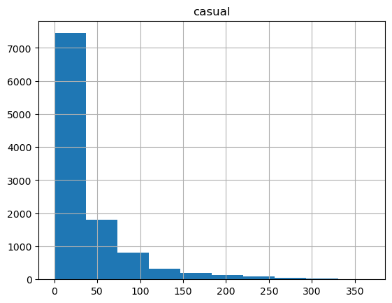

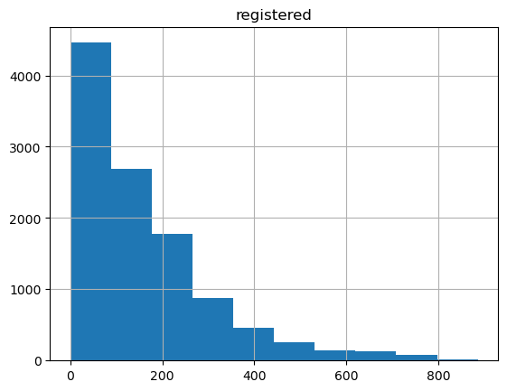

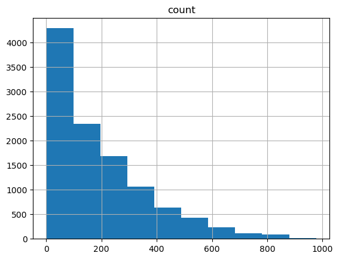

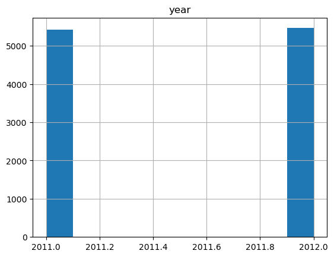

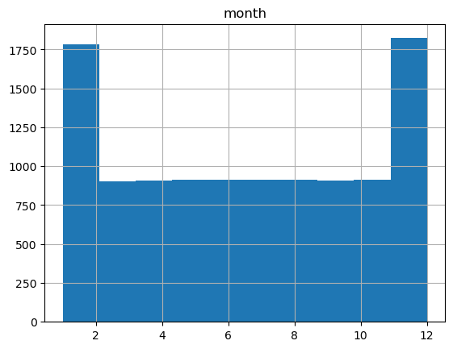

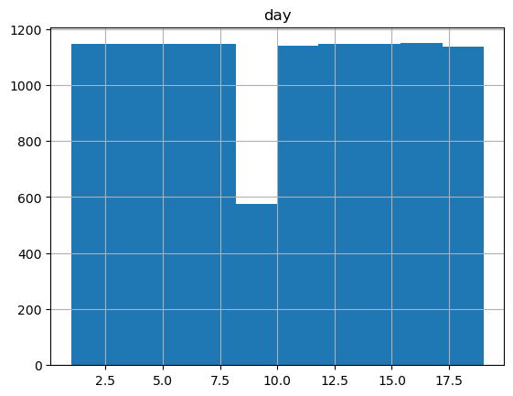

[3 more figures not shown]

```python
# View histogram of all features again now with the hour feature

# Increase the figure size  #start from here
plt.figure(figsize=(10, 6))

# Select only numeric columns from train dataset
numeric_columns = train.select_dtypes(include=['number']).columns

for feature in numeric_columns:
    # Plot the histogram
    train.hist(column=feature)
    # Display the plot
    plt.show()
```

## Step 5: Rerun the model with the same settings as before, just with more features

```python
predictor_new_features = TabularPredictor(label='count',
                             problem_type='regression',
                             eval_metric='root_mean_squared_error',
                             learner_kwargs={"ignored_columns": ["casual", "registered"]}).fit(train_data = train,
                                                                                               time_limit=600,
                                                                                               presets='best_quality')
```

```
No path specified. Models will be saved in: "AutogluonModels\ag-20250527_124244"
Verbosity: 2 (Standard Logging)
=================== System Info ===================
AutoGluon Version:  1.3.0
Python Version:     3.12.4
Operating System:   Windows
Platform Machine:   AMD64
Platform Version:   10.0.26100
CPU Count:          8
Memory Avail:       2.32 GB / 7.81 GB (29.7%)
Disk Space Avail:   13.41 GB / 237.87 GB (5.6%)
===================================================
Presets specified: ['best_quality']
Setting dynamic_stacking from 'auto' to True. Reason: Enable dynamic_stacking when use_bag_holdout is disabled. (use_bag_holdout=False)
Stack configuration (auto_stack=True): num_stack_levels=1, num_bag_folds=8, num_bag_sets=1
DyStack is enabled (dynamic_stacking=True). AutoGluon will try to determine whether the input data is affected by stacked overfitting and enable or disable stacking as a consequence.
	This is used to identify the optimal `num_stack_levels` value. Copies of AutoGluon will be fit on subsets of the data. Then holdout validation data is used to detect stacked overfitting.
	Running DyStack for up to 150s of the 600s of remaining time (25%).
		Context path: "C:\Users\OKKKKK\Documents\udacityawsmlprojects\Project 1 - bikesharingdemand\AutogluonModels\ag-20250527_124244\ds_sub_fit\sub_fit_ho"
Leaderboard on holdout data (DyStack):
                   model  score_holdout   score_val              eval_metric  pred_time_test  pred_time_val   fit_time  pred_time_test_marginal  pred_time_val_marginal  fit_time_marginal  stack_level  can_infer  fit_order
0    WeightedEnsemble_L3     -31.594157  -32.533881  root_mean_squared_error       11.406746      33.554887  90.318776                 0.033359                0.002274           0.069270            3       True          8
1        LightGBM_BAG_L2     -31.597422  -32.974105  root_mean_squared_error       10.833008      32.782697  80.302909                 0.424107                0.306569           7.840566            2       True          7
2      LightGBMXT_BAG_L2     -32.027056  -33.126946  root_mean_squared_error       10.949280      33.246043  82.408940                 0.540379                0.769916           9.946597            2       True          6
3    WeightedEnsemble_L2     -32.603036  -33.317762  root_mean_squared_error       10.225640      32.419588  72.459080                 0.031417                0.000000           0.042186            2       True          5
4        LightGBM_BAG_L1     -33.612144  -34.314730  root_mean_squared_error        1.349454       4.471134  18.470028                 1.349454                4.471134          18.470028            1       True          4
5      LightGBMXT_BAG_L1     -33.853815  -35.313302  root_mean_squared_error        8.659688      27.902202  53.898250                 8.659688               27.902202          53.898250            1       True          3
6  KNeighborsDist_BAG_L1     -92.481676  -89.915546  root_mean_squared_error        0.185081       0.046252   0.048616                 0.185081                0.046252           0.048616            1       True          2
7  KNeighborsUnif_BAG_L1    -109.955256 -107.377627  root_mean_squared_error        0.214678       0.056540   0.045449                 0.214678                0.056540           0.045449            1       True          1
	1	 = Optimal   num_stack_levels (Stacked Overfitting Occurred: False)
	191s	 = DyStack   runtime |	409s	 = Remaining runtime
Starting main fit with num_stack_levels=1.
	For future fit calls on this dataset, you can skip DyStack to save time: `predictor.fit(..., dynamic_stacking=False, num_stack_levels=1)`
Beginning AutoGluon training ... Time limit = 409s
AutoGluon will save models to "C:\Users\OKKKKK\Documents\udacityawsmlprojects\Project 1 - bikesharingdemand\AutogluonModels\ag-20250527_124244"
Train Data Rows:    10886
Train Data Columns: 17
Label Column:       count
Problem Type:       regression
Preprocessing data ...
```

[output cut: 167 more lines]

```
Fitting model: RandomForestMSE_BAG_L2 ... Training model for up to 29.82s of the 29.64s of remaining time.
	-31.7264	 = Validation score   (-root_mean_squared_error)
	19.05s	 = Training   runtime
	1.16s	 = Validation runtime
Fitting model: CatBoost_BAG_L2 ... Training model for up to 8.84s of the 8.66s of remaining time.
	Memory not enough to fit 8 folds in parallel. Will train 4 folds in parallel instead (Estimated 16.41% memory usage per fold, 65.65%/80.00% total).
	Fitting 8 child models (S1F1 - S1F8) | Fitting with ParallelLocalFoldFittingStrategy (4 workers, per: cpus=2, gpus=0, memory=16.41%)
	Time limit exceeded... Skipping CatBoost_BAG_L2.
Fitting model: WeightedEnsemble_L3 ... Training model for up to 360.00s of the -5.69s of remaining time.
	Ensemble Weights: {'LightGBM_BAG_L2': 0.56, 'LightGBMXT_BAG_L2': 0.28, 'RandomForestMSE_BAG_L2': 0.08, 'LightGBMXT_BAG_L1': 0.04, 'CatBoost_BAG_L1': 0.04}
	-30.3113	 = Validation score   (-root_mean_squared_error)
	0.1s	 = Training   runtime
	0.0s	 = Validation runtime
AutoGluon training complete, total runtime = 414.38s ... Best model: WeightedEnsemble_L3 | Estimated inference throughput: 33.3 rows/s (1361 batch size)
TabularPredictor saved. To load, use: predictor = TabularPredictor.load("C:\Users\OKKKKK\Documents\udacityawsmlprojects\Project 1 - bikesharingdemand\AutogluonModels\ag-20250527_124244")
```

```python
predictor_new_features.fit_summary()
```

```
*** Summary of fit() ***
Estimated performance of each model:
                     model   score_val              eval_metric  pred_time_val    fit_time  pred_time_val_marginal  fit_time_marginal  stack_level  can_infer  fit_order
0      WeightedEnsemble_L3  -30.311271  root_mean_squared_error      43.909369  264.842164                0.000000           0.097190            3       True         12
1          LightGBM_BAG_L2  -30.577248  root_mean_squared_error      40.317329  229.577531                0.840558          13.758616            2       True         10
2        LightGBMXT_BAG_L2  -31.113701  root_mean_squared_error      41.904399  231.940802                2.427628          16.121887            2       True          9
3   RandomForestMSE_BAG_L2  -31.726354  root_mean_squared_error      40.641184  234.864470                1.164413          19.045555            2       True         11
4      WeightedEnsemble_L2  -32.406468  root_mean_squared_error      39.425203  215.826327                0.003021           0.075850            2       True          8
5          LightGBM_BAG_L1  -33.917339  root_mean_squared_error       7.838626   24.650964                7.838626          24.650964            1       True          4
6        LightGBMXT_BAG_L1  -34.453884  root_mean_squared_error      29.279091   52.886243               29.279091          52.886243            1       True          3
7          CatBoost_BAG_L1  -37.233593  root_mean_squared_error       0.091189  125.263618                0.091189         125.263618            1       True          6
8     ExtraTreesMSE_BAG_L1  -38.106891  root_mean_squared_error       1.060144    4.765465                1.060144           4.765465            1       True          7
9   RandomForestMSE_BAG_L1  -38.424992  root_mean_squared_error       1.105615    8.115667                1.105615           8.115667            1       True          5
10   KNeighborsDist_BAG_L1  -84.146423  root_mean_squared_error       0.047518    0.068520                0.047518           0.068520            1       True          2
11   KNeighborsUnif_BAG_L1 -101.588176  root_mean_squared_error       0.054588    0.068438                0.054588           0.068438            1       True          1
Number of models trained: 12
Types of models trained:
{'WeightedEnsembleModel', 'StackerEnsembleModel_KNN', 'StackerEnsembleModel_RF', 'StackerEnsembleModel_XT', 'StackerEnsembleModel_LGB', 'StackerEnsembleModel_CatBoost'}
Bagging used: True  (with 8 folds)
Multi-layer stack-ensembling used: True  (with 3 levels)
Feature Metadata (Processed):
(raw dtype, special dtypes):
('category', [])             : 2 | ['season', 'weather']
('float', [])                : 3 | ['temp', 'atemp', 'windspeed']
('int', [])                  : 4 | ['humidity', 'month', 'day', 'hour']
('int', ['bool'])            : 3 | ['holiday', 'workingday', 'year']
('int', ['datetime_as_int']) : 3 | ['datetime', 'datetime.year', 'datetime.dayofweek']
Plot summary of models saved to file: C:\Users\OKKKKK\Documents\udacityawsmlprojects\Project 1 - bikesharingdemand\AutogluonModels\ag-20250527_124244\SummaryOfModels.html
*** End of fit() summary ***
```

[output not shown]

[output cut: 150 more lines]

```
 11       0.054588    0.068438                0.054588           0.068438

     stack_level  can_infer  fit_order
 0             3       True         12
 1             2       True         10
 2             2       True          9
 3             2       True         11
 4             2       True          8
 5             1       True          4
 6             1       True          3
 7             1       True          6
 8             1       True          7
 9             1       True          5
 10            1       True          2
 11            1       True          1  }
```

```python
# Note: By setting as_pandas=True, the predicted output will be returned as a Pandas DataFrame.
# predictor.predict(test_data, model='LightGBM')

# predicting with the test dataset
predictions_new_features = predictor_new_features.predict(test)
predictions_new_features.head()
```

[output not shown]

```
0    15.015905
1     9.935132
2     8.961338
3     7.983731
4     6.635027
Name: count, dtype: float32
```

```python
predictions_new_features.describe()
```

```
count    6493.000000
mean      163.141174
std       145.061920
min         1.773188
25%        49.447643
50%       126.696579
75%       231.119812
max       813.643677
Name: count, dtype: float64
```

```python
# counting the negative values

negative_count_new_features = (predictions_new_features < 0).sum()
print(f'Negative values count: {negative_count_new_features}')
```

```
Negative values count: 0
```

```python
# Remember to set all negative values to greater than zero

# Set them to zero
predictions_new_features[predictions_new_features < 0] = 0

negative_count_new_features = (predictions_new_features < 0).sum()
print(f'Negative values count: {negative_count_new_features}')
```

```
Negative values count: 0
```

```python
# Same submitting predictions
submission_new_features["count"] = predictions_new_features
submission_new_features.to_csv("submission_new_features.csv", index=False)
```

```python
view_second_submission = pd.read_csv('submission_new_features.csv')
view_second_submission.head(2)
```

|  | datetime | count |
| --- | --- | --- |
| 0 | 2011-01-20 00:00:00 | 15.015905 |
| 1 | 2011-01-20 01:00:00 | 9.935132 |

```python
!kaggle competitions submit -c bike-sharing-demand -f submission_new_features.csv -m "new features"
```

```
Successfully submitted to Bike Sharing Demand
```

```
  8%|8         | 16.0k/195k [00:00<00:05, 33.1kB/s]
 49%|####9     | 96.0k/195k [00:00<00:00, 170kB/s]
 66%|######5   | 128k/195k [00:00<00:00, 155kB/s]
 82%|########2 | 160k/195k [00:01<00:00, 155kB/s]
```

```python
# Running the Kaggle command and storing the output in a variable
output = !kaggle competitions submissions -c bike-sharing-demand

# Displaying the first 6 lines
for line in output[:6]:
    print(line)
```

[output not shown]

#### New Score of `0.62281`

## Step 6: Hyper parameter optimization

- There are many options for hyper parameter optimization.
- Options are to change the AutoGluon higher level parameters or the individual model hyperparameters.
- The hyperparameters of the models themselves that are in AutoGluon. Those need the `hyperparameter` and `hyperparameter_tune_kwargs` arguments.

```python
predictor_new_hpo = TabularPredictor(label='count',
                             problem_type='regression',
                             eval_metric='root_mean_squared_error',
                             learner_kwargs={"ignored_columns": ["casual", "registered"]}
                            ).fit(train_data = train,
                                  time_limit=600,
                                  presets='best_quality',
                                 hyperparameters={'RF': {'n_estimators': 300},
                                                  'XGB': {'n_estimators': 100, 'learning_rate': 0.1},
                                                  'GBM': {},
                                                  'CAT': {}},
                                  hyperparameter_tune_kwargs={'num_trials': 10,
                                                              'scheduler': 'local',
                                                              'searcher': 'random'})
```

```
No path specified. Models will be saved in: "AutogluonModels\ag-20250527_125327"
Verbosity: 2 (Standard Logging)
=================== System Info ===================
AutoGluon Version:  1.3.0
Python Version:     3.12.4
Operating System:   Windows
Platform Machine:   AMD64
Platform Version:   10.0.26100
CPU Count:          8
Memory Avail:       2.17 GB / 7.81 GB (27.7%)
Disk Space Avail:   12.43 GB / 237.87 GB (5.2%)
===================================================
Presets specified: ['best_quality']
Warning: hyperparameter tuning is currently experimental and may cause the process to hang.
Setting dynamic_stacking from 'auto' to True. Reason: Enable dynamic_stacking when use_bag_holdout is disabled. (use_bag_holdout=False)
Stack configuration (auto_stack=True): num_stack_levels=1, num_bag_folds=8, num_bag_sets=1
DyStack is enabled (dynamic_stacking=True). AutoGluon will try to determine whether the input data is affected by stacked overfitting and enable or disable stacking as a consequence.
	This is used to identify the optimal `num_stack_levels` value. Copies of AutoGluon will be fit on subsets of the data. Then holdout validation data is used to detect stacked overfitting.
	Running DyStack for up to 150s of the 600s of remaining time (25%).
		Context path: "C:\Users\OKKKKK\Documents\udacityawsmlprojects\Project 1 - bikesharingdemand\AutogluonModels\ag-20250527_125327\ds_sub_fit\sub_fit_ho"
Leaderboard on holdout data (DyStack):
                 model  score_holdout  score_val              eval_metric  pred_time_test  pred_time_val    fit_time  pred_time_test_marginal  pred_time_val_marginal  fit_time_marginal  stack_level  can_infer  fit_order
0   LightGBM_BAG_L1\T1     -33.612144 -34.314730  root_mean_squared_error        5.929065       4.375983   37.656000                 5.929065                4.375983          37.656000            1       True          1
1  WeightedEnsemble_L3     -33.663930 -33.656216  root_mean_squared_error       13.428471       7.585928  165.926997                 0.037265                0.000000           0.069227            3       True          9
2   LightGBM_BAG_L2\T1     -33.741474 -34.332587  root_mean_squared_error       11.602427       6.134007  126.876879                 0.397411                0.191034          23.358074            2       True          6
3  WeightedEnsemble_L2     -33.911586 -33.709151  root_mean_squared_error        7.969670       5.860441   67.036200                 0.034589                0.002021           0.054722            2       True          5
4    XGBoost_BAG_L2\T1     -33.950223 -34.705474  root_mean_squared_error       12.114305       6.245425  124.212515                 0.909289                0.302452          20.693710            2       True          8
5  RandomForest_BAG_L2     -34.431222 -34.999293  root_mean_squared_error       12.084506       7.092442  121.805985                 0.879490                1.149469          18.287180            2       True          7
6    XGBoost_BAG_L1\T1     -36.854370 -38.919426  root_mean_squared_error        0.811739       0.374721   18.928230                 0.811739                0.374721          18.928230            1       True          4
7  RandomForest_BAG_L1     -40.393519 -38.935123  root_mean_squared_error        1.194277       1.107716   10.397248                 1.194277                1.107716          10.397248            1       True          2
8   CatBoost_BAG_L1\T1     -65.641700 -65.313679  root_mean_squared_error        3.269935       0.084553   36.537327                 3.269935                0.084553          36.537327            1       True          3
	1	 = Optimal   num_stack_levels (Stacked Overfitting Occurred: False)
	209s	 = DyStack   runtime |	391s	 = Remaining runtime
Starting main fit with num_stack_levels=1.
	For future fit calls on this dataset, you can skip DyStack to save time: `predictor.fit(..., dynamic_stacking=False, num_stack_levels=1)`
Beginning AutoGluon training ... Time limit = 391s
AutoGluon will save models to "C:\Users\OKKKKK\Documents\udacityawsmlprojects\Project 1 - bikesharingdemand\AutogluonModels\ag-20250527_125327"
Train Data Rows:    10886
Train Data Columns: 17
Label Column:       count
```

[output cut: 39 more lines]

```
	Train Data (Processed) Memory Usage: 0.76 MB (0.0% of available memory)
Data preprocessing and feature engineering runtime = 2.67s ...
AutoGluon will gauge predictive performance using evaluation metric: 'root_mean_squared_error'
	This metric's sign has been flipped to adhere to being higher_is_better. The metric score can be multiplied by -1 to get the metric value.
	To change this, specify the eval_metric parameter of Predictor()
User-specified model hyperparameters to be fit:
{
	'RF': [{'n_estimators': 300}],
	'XGB': [{'n_estimators': 100, 'learning_rate': 0.1}],
	'GBM': [{}],
	'CAT': [{}],
}
AutoGluon will fit 2 stack levels (L1 to L2) ...
Fitting 4 L1 models, fit_strategy="sequential" ...
Hyperparameter tuning model: LightGBM_BAG_L1 ... Tuning model for up to 58.22s of the 388.21s of remaining time.
```

```
	Fitting 8 child models (S1F1 - S1F8) | Fitting with ParallelLocalFoldFittingStrategy (8 workers, per: cpus=1, gpus=0, memory=0.46%)
	Stopping HPO to satisfy time limit...
Fitted model: LightGBM_BAG_L1\T1 ...
	-33.9173	 = Validation score   (-root_mean_squared_error)
	45.3s	 = Training   runtime
	6.81s	 = Validation runtime
Hyperparameter tuning model: RandomForest_BAG_L1 ... Tuning model for up to 58.22s of the 342.65s of remaining time.
	No hyperparameter search space specified for RandomForest_BAG_L1. Skipping HPO. Will train one model based on the provided hyperparameters.
Fitted model: RandomForest_BAG_L1 ...
	-38.425	 = Validation score   (-root_mean_squared_error)
	12.72s	 = Training   runtime
	1.56s	 = Validation runtime
Hyperparameter tuning model: CatBoost_BAG_L1 ... Tuning model for up to 58.22s of the 329.81s of remaining time.
```

[output not shown]

```
	Fitting 8 child models (S1F1 - S1F8) | Fitting with ParallelLocalFoldFittingStrategy (8 workers, per: cpus=1, gpus=0, memory=1.16%)
	Stopping HPO to satisfy time limit...
Fitted model: XGBoost_BAG_L1\T1 ...
	-38.0285	 = Validation score   (-root_mean_squared_error)
	30.96s	 = Training   runtime
	0.47s	 = Validation runtime
Fitting model: WeightedEnsemble_L2 ... Training model for up to 360.00s of the 231.48s of remaining time.
	Ensemble Weights: {'LightGBM_BAG_L1\T1': 0.7, 'RandomForest_BAG_L1': 0.2, 'XGBoost_BAG_L1\T1': 0.1}
	-33.3149	 = Validation score   (-root_mean_squared_error)
	0.06s	 = Training   runtime
	0.0s	 = Validation runtime
Fitting 4 L2 models, fit_strategy="sequential" ...
Hyperparameter tuning model: LightGBM_BAG_L2 ... Tuning model for up to 52.05s of the 231.31s of remaining time.
```

```
	Fitting 8 child models (S1F1 - S1F8) | Fitting with ParallelLocalFoldFittingStrategy (8 workers, per: cpus=1, gpus=0, memory=1.52%)
	Stopping HPO to satisfy time limit...
Fitted model: LightGBM_BAG_L2\T1 ...
	-152.7194	 = Validation score   (-root_mean_squared_error)
	26.77s	 = Training   runtime
	0.11s	 = Validation runtime
Hyperparameter tuning model: RandomForest_BAG_L2 ... Tuning model for up to 52.05s of the 204.14s of remaining time.
	No hyperparameter search space specified for RandomForest_BAG_L2. Skipping HPO. Will train one model based on the provided hyperparameters.
	Warning: Reducing model 'n_estimators' from 300 -> 91 due to low memory. Expected memory usage reduced from 49.1% -> 15.0% of available memory...
Fitted model: RandomForest_BAG_L2 ...
	-34.8003	 = Validation score   (-root_mean_squared_error)
	8.59s	 = Training   runtime
	0.57s	 = Validation runtime
Hyperparameter tuning model: CatBoost_BAG_L2 ... Tuning model for up to 52.05s of the 195.4s of remaining time.
```

[output not shown]

```
2025-05-27 14:00:54,136	ERROR worker.py:420 -- Unhandled error (suppress with 'RAY_IGNORE_UNHANDLED_ERRORS=1'): The worker died unexpectedly while executing this task. Check python-core-worker-*.log files for more information.
	Fitting 8 child models (S1F1 - S1F8) | Fitting with ParallelLocalFoldFittingStrategy (8 workers, per: cpus=1, gpus=0, memory=0.94%)
	Fitting 8 child models (S1F1 - S1F8) | Fitting with ParallelLocalFoldFittingStrategy (8 workers, per: cpus=1, gpus=0, memory=4.25%)
	Stopping HPO to satisfy time limit...
Fitted model: XGBoost_BAG_L2\T1 ...
	-34.4184	 = Validation score   (-root_mean_squared_error)
	20.34s	 = Training   runtime
	0.34s	 = Validation runtime
Fitted model: XGBoost_BAG_L2\T2 ...
	-34.6589	 = Validation score   (-root_mean_squared_error)
	23.34s	 = Training   runtime
	0.45s	 = Validation runtime
Fitting model: WeightedEnsemble_L3 ... Training model for up to 360.00s of the 109.65s of remaining time.
	Ensemble Weights: {'LightGBM_BAG_L1\T1': 0.545, 'RandomForest_BAG_L1': 0.136, 'RandomForest_BAG_L2': 0.136, 'XGBoost_BAG_L1\T1': 0.091, 'XGBoost_BAG_L2\T2': 0.091}
	-33.2446	 = Validation score   (-root_mean_squared_error)
	0.15s	 = Training   runtime
	0.0s	 = Validation runtime
AutoGluon training complete, total runtime = 281.56s ... Best model: WeightedEnsemble_L3 | Estimated inference throughput: 168.1 rows/s (1361 batch size)
TabularPredictor saved. To load, use: predictor = TabularPredictor.load("C:\Users\OKKKKK\Documents\udacityawsmlprojects\Project 1 - bikesharingdemand\AutogluonModels\ag-20250527_125327")
```

```python
predictor_new_hpo.fit_summary()
```

```
*** Summary of fit() ***
Estimated performance of each model:
                 model   score_val              eval_metric  pred_time_val    fit_time  pred_time_val_marginal  fit_time_marginal  stack_level  can_infer  fit_order
0  WeightedEnsemble_L3  -33.244624  root_mean_squared_error       9.965187  187.902722                0.004046           0.151327            3       True         10
1  WeightedEnsemble_L2  -33.314868  root_mean_squared_error       8.838804   89.041932                0.002023           0.063049            2       True          5
2   LightGBM_BAG_L1\T1  -33.917339  root_mean_squared_error       6.810178   45.299117                6.810178          45.299117            1       True          1
3    XGBoost_BAG_L2\T1  -34.418369  root_mean_squared_error       9.279751  176.150548                0.335045          20.337509            2       True          8
4    XGBoost_BAG_L2\T2  -34.658917  root_mean_squared_error       9.391183  179.157420                0.446476          23.344381            2       True          9
5  RandomForest_BAG_L2  -34.800299  root_mean_squared_error       9.514664  164.407014                0.569958           8.593975            2       True          7
6    XGBoost_BAG_L1\T1  -38.028550  root_mean_squared_error       0.465850   30.959189                0.465850          30.959189            1       True          4
7  RandomForest_BAG_L1  -38.424992  root_mean_squared_error       1.560753   12.720577                1.560753          12.720577            1       True          2
8   CatBoost_BAG_L1\T1  -45.631889  root_mean_squared_error       0.107925   66.834156                0.107925          66.834156            1       True          3
9   LightGBM_BAG_L2\T1 -152.719445  root_mean_squared_error       9.054014  182.581235                0.109308          26.768196            2       True          6
Number of models trained: 10
Types of models trained:
{'WeightedEnsembleModel', 'StackerEnsembleModel_XGBoost', 'StackerEnsembleModel_RF', 'StackerEnsembleModel_LGB', 'StackerEnsembleModel_CatBoost'}
Bagging used: True  (with 8 folds)
Multi-layer stack-ensembling used: True  (with 3 levels)
Feature Metadata (Processed):
(raw dtype, special dtypes):
('category', [])             : 2 | ['season', 'weather']
('float', [])                : 3 | ['temp', 'atemp', 'windspeed']
('int', [])                  : 4 | ['humidity', 'month', 'day', 'hour']
('int', ['bool'])            : 3 | ['holiday', 'workingday', 'year']
('int', ['datetime_as_int']) : 3 | ['datetime', 'datetime.year', 'datetime.dayofweek']
Plot summary of models saved to file: C:\Users\OKKKKK\Documents\udacityawsmlprojects\Project 1 - bikesharingdemand\AutogluonModels\ag-20250527_125327\SummaryOfModels.html
*** End of fit() summary ***
```

[output not shown]

[output cut: 115 more lines]

```
 7   12.720577                1.560753          12.720577            1
 8   66.834156                0.107925          66.834156            1
 9  182.581235                0.109308          26.768196            2

    can_infer  fit_order
 0       True         10
 1       True          5
 2       True          1
 3       True          8
 4       True          9
 5       True          7
 6       True          4
 7       True          2
 8       True          3
 9       True          6  }
```

```python
# Note: By setting as_pandas=True, the predicted output will be returned as a Pandas DataFrame.
# predictor.predict(test_data, model='LightGBM')

predictions_new_hpo = predictor_new_hpo.predict(test)
predictions_new_hpo
```

```
0        14.307319
1         2.707309
2         0.784421
3         2.585376
4         2.495420
           ...
6488    349.967651
6489    231.884659
6490    154.408447
6491    105.188255
6492     51.298176
Name: count, Length: 6493, dtype: float32
```

```python
# Remember to set all negative values to zero

# Set them to zero
predictions_new_hpo[predictions_new_hpo < 0] = 0

negative_count_new_hpo = (predictions_new_hpo < 0).sum()
print(f'Negative values count: {negative_count_new_hpo}')
```

```
Negative values count: 0
```

```python
 # Same submitting predictions
submission_new_hpo["count"] = predictions_new_hpo
submission_new_hpo.to_csv("submission_new_hpo.csv", index=False)
```

```python
view_third_submission = pd.read_csv('submission_new_features.csv')
view_third_submission.head(2)
```

|  | datetime | count |
| --- | --- | --- |
| 0 | 2011-01-20 00:00:00 | 15.015905 |
| 1 | 2011-01-20 01:00:00 | 9.935132 |

```python
!kaggle competitions submit -c bike-sharing-demand -f submission_new_hpo.csv -m "new features with hyperparameters"
```

```
Successfully submitted to Bike Sharing Demand
```

```
  8%|8         | 16.0k/194k [00:00<00:06, 29.4kB/s]
 49%|####9     | 96.0k/194k [00:00<00:00, 162kB/s]
 66%|######5   | 128k/194k [00:00<00:00, 152kB/s]
 82%|########2 | 160k/194k [00:01<00:00, 161kB/s]
```

```python
# Running the Kaggle command and storing the output in a variable
output = !kaggle competitions submissions -c bike-sharing-demand

# Displaying the first 6 lines
for line in output[:6]:
    print(line)
```

```
fileName                     date                        description                        status                     publicScore  privateScore
---------------------------  --------------------------  ---------------------------------  -------------------------  -----------  ------------
submission_new_hpo.csv       2025-05-27 13:01:55.393000  new features with hyperparameters  SubmissionStatus.COMPLETE  0.49398      0.49398
submission_new_features.csv  2025-05-27 12:53:24.687000  new features                       SubmissionStatus.COMPLETE  0.62281      0.62281
submission1.csv              2025-05-27 12:40:48.563000  first raw submission               SubmissionStatus.COMPLETE  1.79857      1.79857
submission1.csv              2025-05-23 12:50:44.947000  first raw submission               SubmissionStatus.COMPLETE  1.80029      1.80029
```

#### New Score of `0.49398`

## Step 7: Write a Report

### Refer to the markdown file for the full report

### Creating plots and table for report

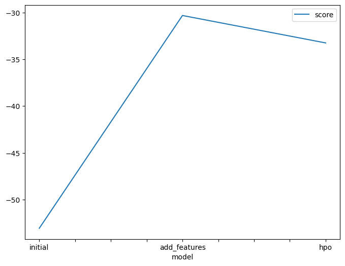

```python
# Taking the top model score from each training run and creating a line plot to show improvement
# You can create these in the notebook and save them to PNG or use some other tool (e.g. google sheets, excel)
fig = pd.DataFrame(
    {
        "model": ["initial", "add_features", "hpo"],
        "score": [-53.073554, -30.311271, -33.244624]
    }
).plot(x="model", y="score", figsize=(8, 6)).get_figure()
fig.savefig('model_train_score.png')
```

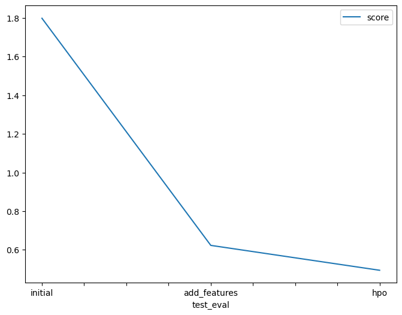

```python
# Take the 3 kaggle scores and creating a line plot to show improvement
fig = pd.DataFrame(
    {
        "test_eval": ["initial", "add_features", "hpo"],
        "score": [1.79857, 0.62281, 0.49398]
    }
).plot(x="test_eval", y="score", figsize=(8, 6)).get_figure()
fig.savefig('model_test_score.png')
```

### Hyperparameter table

```python
# The 3 hyperparameters we tuned with the kaggle score as the result
pd.DataFrame({
    "model": ["initial", "add_features", "hpo"],
    "hpo1": ["default", "default", "RF: n_estimators=300"],
    "hpo2": ["default", "default", "XGB: n_estimators=100"],
    "hpo3": ["default", "default", "XGB: learning_rate=0.1"],
    "score": [1.79857, 0.62281, 0.49398]
})
```

|  | model | hpo1 | hpo2 | hpo3 | score |
| --- | --- | --- | --- | --- | --- |
| 0 | initial | default | default | default | 1.79857 |
| 1 | add_features | default | default | default | 0.62281 |
| 2 | hpo | RF: n_estimators=300 | XGB: n_estimators=100 | XGB: learning_rate=0.1 | 0.49398 |